# 1. Introduction

This report will be following the workflow of the Chollet's universal workflow of machine learning from Deep Learning with Python (1st Edition)'s Chapter 4.5, as a blueprint to explore machine learning problems. I will be using Chollet's workflow to develop a model to prove my hypotheses.

# 2. Defining the problem and assembling a dataset

The problem that I will be addressing or looking at in this report will be multiclass image classification using the Modified National Institute of Standards and Technology (MNIST) database from TensorFlow. The MNIST database of handwritten digits has a training set of 60,000 examples, and a test set of 10,000 examples. This dataset is a collection of handwritten digits, and has a training set of 60,000 examples.

There are 10 classes in total, which are for single digit numbers ranging from 0 - 9.

## 2.1 Hypotheses

The hypothesis is that it should be possible to predict the output with a given input as there should exist a predictive relationship between the pixel values of an input image and its corresponding label, such as patterns in the arrangement of pixels in images that consistently correspond to specific numbers.

The other hypothesis is the MNIST dataset provided is sufficiently informative to learn the relationship between inputs and outputs.

# 3. Choosing a measure of success

The measure of success will be accuracy, as there is no class imbalance in this dataset.

Accuracy is the proportion of correctly classified samples out of the total number of samples. In a multi-class, single-label problem, each data point has a single "correct" class, making accuracy an intuitive metric to gauge the overall model performance.

# 4. Deciding on an evaluation protocol

Out of the three evaluation protocols mentioned in the DLWP book, the best one that will fit the dataset will be maintaining a hold-out set. As the book mentioned, it is the right choice when you have plenty of data. In our case, our dataset contains 60,000 examples for training, which we can split it up to use for validation during training, while still maintaining enough samples for training. We also have the 10,000 sample test set for us to test our final model. Therefore, creating a hold-out set would be optimal for our project.

# 5. Preparing your data

## 5.1 Loading and reading the dataset

Firstly, I will import related external libraries to help me load in the dataset.

```python
# Importing libraries
import os
import random
import numpy as np

from sklearn.metrics import accuracy_score

import tensorflow as tf
from keras.datasets import mnist

import itertools
import matplotlib.pyplot as plt

import warnings
warnings.filterwarnings('ignore')

#Sets a specific seed to replicate the results
SEED = 50

tf.random.set_seed(SEED)
np.random.seed(SEED)
```

```
WARNING:tensorflow:From C:\Python\Python310\lib\site-packages\keras\src\losses.py:2976: The name tf.losses.sparse_softmax_cross_entropy is deprecated. Please use tf.compat.v1.losses.sparse_softmax_cross_entropy instead.
```

```python
#Loading the MNIST Dataset
(X_train, y_train), (X_test, y_test) = mnist.load_data()

# Dataset Summary
print('Train: X=%s, y=%s' % (X_train.shape, y_train.shape))
print('Test: X=%s, y=%s' % (X_test.shape, y_test.shape))
```

```
Train: X=(60000, 28, 28), y=(60000,)
Test: X=(10000, 28, 28), y=(10000,)
```

## 5.2 The MNIST Data

As mentioned above, the MNIST dataset consists of a training set of 60,000 examples, where each example is a 28x28 greyscale image. Below is an example of how the images look like.

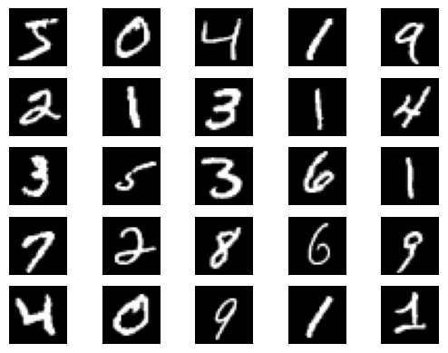

```python
nrows = 5 # Number of rows in the grid
ncols = 5 # Number of columns in the grid

# For loop to display 25 amount of images
for i in range(25):
  row = i // ncols
  col = i % ncols
  index = row * ncols + col + 1
  plt.subplot(nrows, ncols, index)
  plt.imshow(X_train[i], cmap=plt.get_cmap('gray'))

  # Turn off grid lines and axes
  plt.grid(False)
  plt.axis('off')

plt.show()
```

## 5.3 Formatting the data

We have to first format the data as tensors such that it can be fed into a machine-learning model, therefore the values taken by these tensors should usually be scaled to small values such as the [-1, 1] or [0, 1] range.

Given that the pixel-value is an integer between 0 and 255, we will have to normalise it from [0, 255] to [0, 1].

```python
# Normalise pixels from [0, 255] to [0, 1]
X_train, X_test = X_train/255, X_test/255
```

## 5.4 Encoding the data

Encoding the data is also another important pre-processing step as it converts the categorical data into numerical format, to be able to use as input for algorithms to process.

Given that the MNIST dataset contains 10 different classes represented by the digits 0-9, an encoding method we can use is one-hot encoding. This technique will transform each class label into a 10-element vector, making them suitable for machine learning models.

I will use TensorFlow's utility function `to_categorical` to aid me in performing the one-hot encoding.

```python
from keras.utils import to_categorical

# one hot encoded target values
y_train_encoded = to_categorical(y_train, num_classes=10)
y_test_encoded = to_categorical(y_test, num_classes=10)
```

## 5.5 Hold-out set

I will now proceed to create a hold-out set, which is a subset of my training data. This hold-out set will aid in evaluating the accuracy of my model during the training process. The hold-out set will be 20% of my current training data.

```python
from sklearn.model_selection import train_test_split

VALIDATION_SIZE = 0.2

#X_val and Y_val is the hold-out set
X_train, X_validation, y_train, y_validation = train_test_split(X_train, y_train_encoded,
                                                  test_size=VALIDATION_SIZE,
                                                  stratify=y_train,
                                                  shuffle=True,
                                                  random_state=SEED) #Apply the SEED at the end to replicate results.
```

```python
print("Training Set Size:", X_train.shape[0])
print("Hold-Out Set Size:", X_validation.shape[0])
print("Test Set Size:", X_test.shape[0])
```

```
Training Set Size: 48000
Hold-Out Set Size: 12000
Test Set Size: 10000
```

As seen above, the final sizes of each set is as follows:

- The **training set**, consisting of 48000 samples, 80% of the original training set.
- The **hold-out set**, consisting of 12000, 20% of the original training set.
- The **test set**, consisting of 10000 samples.

# 6. Developing a model that does better than a baseline

As mentioned in the book, the goal of this stage is to achieve statistical power by developing a small model that is capable of beating a baseline.

Assuming that things go well, the three key choices - Last-layer activation, Loss function, and Optimization configuration will have to be chosen to build the first working model.

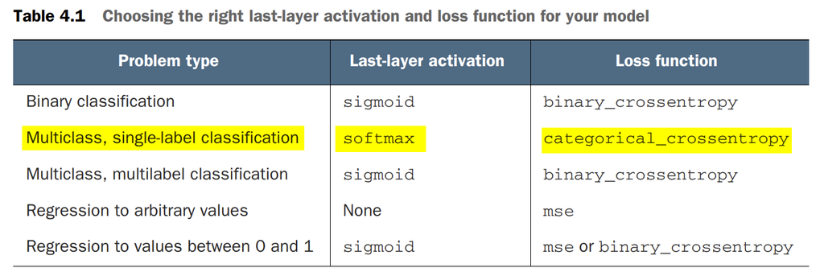

Based on Table 4.1 of the DLWP Book, given our problem and dataset, it would be a **Multiclass, single-label classification**. According to the table, the last-layer activation would be **softmax**, and **categorical_crossentropy** will be the loss function.

The book also mentions that the **rmsprop** is a safe optimizer to use in most cases, therefore we will proceed using **rmsprop** as the optimizer and its default learning rate.

## 6.1 The Baseline

Before developing a model, we have to come up with the baseline to work with, to be able to develop a model that will do better than the baseline. As we have learnt in this module, I will be using the Naive classification models as my baseline to compare with the model that I will develop.

As I have split the dataset up, and I am unsure whether the classes are perfectly balanced, I will be using the Naive Majority Classification model to create my baseline, to be used as a point of reference against the model that I will develop later. The Naive Majority Classification model will predict that the majority class amongst all other instances will be the correct prediction in the classification problem.

**Labels**

- 1
- 2
- 3
- 4

and the respective sample size for each are:

**Sample Size**

- 5000
- 4000
- 3000
- 2000

It will then predict 1 for all instances.

```python
from collections import Counter

# Converting one-hot encoded labels back to integer labels
y_train_labels = np.argmax(y_train, axis=1)

# Extracts the count of the most common label in the set
highest_label = Counter(y_train_labels).most_common(1)[0][0]
highest_label_count = Counter(y_train_labels).most_common(1)[0][1]

# Calculates a naive accuracy score
naive_y_pred = highest_label_count / len(y_test)

# Prints out the respective data
print("Label with the highest number of samples in the training set:")
print("Label: %s, with count of %s samples" % (highest_label, highest_label_count))
print("Naive Baseline Accuracy: {:0.2f}%".format(naive_y_pred * 100))
```

[output not shown]

Based on the above calculations, we have managed to calculate the label with the most samples in our training set, which is the label 1, having 5394 samples.

We will proceed on to develop and train a model to beat this baseline.

## 6.2 Developing the model

```python
# Helper function to plot training and validation loss
def plot_training_loss(history, axes):
    loss, val_loss = history.history['loss'], history.history['val_loss']
    epochs = range(1, len(loss) + 1)

    axes[0].plot(epochs, loss, 'blue', label='Training Loss')
    axes[0].plot(epochs, val_loss, 'orange', label='Validation Loss')
    axes[0].set_title('Training and Validation Loss')
    axes[0].set_xlabel('Epochs')
    axes[0].set_ylabel('Loss')
    axes[0].legend()
    axes[0].grid()



# Helper function to plot training and validation categorical accuracy
def plot_training_accuracy(history, axes):
    acc, val_acc = history.history['categorical_accuracy'], history.history['val_categorical_accuracy']
    epochs = range(1, len(acc) + 1)

    # Converts to %
    acc = [x * 100 for x in acc]
    val_acc = [x * 100 for x in val_acc]

    axes[1].plot(epochs, acc, 'blue', label='Training Accuracy')
    axes[1].plot(epochs, val_acc, 'orange', label='Validation Accuracy')
    axes[1].set_title('Training and Validation Accuracy')
    axes[1].set_xlabel('Epochs')
    axes[1].set_ylabel('Accuracy (%)')
    axes[1].legend()
    axes[1].grid()
```

```python
# Importing libraries and modules
from keras.models import Sequential
from keras.layers import Dense, Dropout, Flatten
from keras.callbacks import EarlyStopping
from tensorflow.keras.optimizers import RMSprop

# Shape of the model to flatten
INPUT_DIMENSION = (28, 28)

# Output classes - defaulted to our class size
OUTPUT_CLASSES = 10

# Batch size - how fast our model learns
batch_size = 64

# Amount of epochs to train
EPOCHS = 10

# rmsprop optimizer
OPTIMIZER = 'rmsprop'

# categorical_crossentropy loss function
LOSS_FUNC = 'categorical_crossentropy'

# accuracy metric
METRICS = ['categorical_accuracy']

# Number of epochs with no improvement after which training will be stopped.
PATIENCE = 5

# Stops the training early to prevent overfitting
EARLY_STOP = EarlyStopping(monitor='val_loss', restore_best_weights=True, patience=PATIENCE, verbose=0)
```

```python
# Creating the model
beatBaselineModel = Sequential([
                        Flatten(input_shape=INPUT_DIMENSION, name="flatten"),
                        Dense(OUTPUT_CLASSES, activation='softmax')
                    ], name='beatBaselineModel')

# Prints out the summary of the model
beatBaselineModel.summary()
```

```
WARNING:tensorflow:From C:\Python\Python310\lib\site-packages\keras\src\backend.py:873: The name tf.get_default_graph is deprecated. Please use tf.compat.v1.get_default_graph instead.

Model: "beatBaselineModel"
_________________________________________________________________
 Layer (type)                Output Shape              Param #
=================================================================
 flatten (Flatten)           (None, 784)               0

 dense (Dense)               (None, 10)                7850

=================================================================
Total params: 7850 (30.66 KB)
Trainable params: 7850 (30.66 KB)
Non-trainable params: 0 (0.00 Byte)
_________________________________________________________________
```

```python
# Compiling the model
beatBaselineModel.compile(optimizer=OPTIMIZER,
                         loss=LOSS_FUNC, metrics=METRICS)

# Training the model
beatBaselineModel_history = beatBaselineModel.fit(X_train, y_train,
                                                  batch_size=batch_size, epochs=EPOCHS,
                                                  validation_data=(X_validation, y_validation),
                                                  callbacks=[EARLY_STOP],
                                                  verbose=1)

# Evaluate the model on the validation set
test_loss, test_acc = beatBaselineModel.evaluate(X_validation, y_validation)
print('Validation Accuracy: {:.2f}%'.format(test_acc * 100))
```

```
WARNING:tensorflow:From C:\Python\Python310\lib\site-packages\keras\src\optimizers\__init__.py:309: The name tf.train.Optimizer is deprecated. Please use tf.compat.v1.train.Optimizer instead.

WARNING:tensorflow:From C:\Python\Python310\lib\site-packages\keras\src\utils\tf_utils.py:492: The name tf.ragged.RaggedTensorValue is deprecated. Please use tf.compat.v1.ragged.RaggedTensorValue instead.

WARNING:tensorflow:From C:\Python\Python310\lib\site-packages\keras\src\engine\base_layer_utils.py:384: The name tf.executing_eagerly_outside_functions is deprecated. Please use tf.compat.v1.executing_eagerly_outside_functions instead.

Validation Accuracy: 91.94%
```

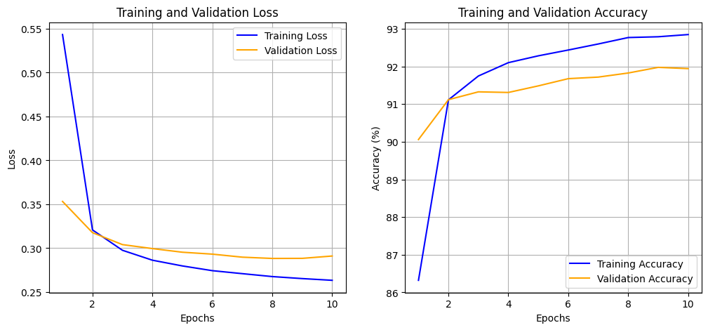

```python
# Plotting
fig, axes = plt.subplots(1, 2, figsize=(12, 5))
plot_training_loss(beatBaselineModel_history, axes)
plot_training_accuracy(beatBaselineModel_history, axes)
plt.show()
```

# 7. Developing a model that overfits

After developing a model that have enough statistical power, we will have to validate our model to ensure that it is ideal, meaning that it stands right at the border between underfitting and overfitting. Therefore, we will develop a model that overfits to find out where the border lies at.

There are 3 ways to do this:

- Add layers.
- Make the layers bigger.
- Train for more epochs.

We will now proceed on to develop the overfitting model using all 3 methods mentioned above.

```python
# Overfitted model with more layers
overfittedModel = Sequential([
                    Flatten(input_shape=INPUT_DIMENSION, name='flatten'),
                    # Added more layers
                    Dense(256, activation='relu'), #Made the layers bigger
                    Dense(128, activation='relu'),
                    Dense(64, activation='relu'),
                    Dense(64, activation='relu'),
                    Dense(48, activation='relu'),
                    Dense(32, activation='relu'),
                    Dense(OUTPUT_CLASSES, activation='softmax')
], name='overfittedModel')

overfittedModel.summary()
```

```
Model: "overfittedModel"
_________________________________________________________________
 Layer (type)                Output Shape              Param #
=================================================================
 flatten (Flatten)           (None, 784)               0

 dense_1 (Dense)             (None, 256)               200960

 dense_2 (Dense)             (None, 128)               32896

 dense_3 (Dense)             (None, 64)                8256

 dense_4 (Dense)             (None, 64)                4160

 dense_5 (Dense)             (None, 48)                3120

 dense_6 (Dense)             (None, 32)                1568

 dense_7 (Dense)             (None, 10)                330

=================================================================
Total params: 251290 (981.60 KB)
Trainable params: 251290 (981.60 KB)
Non-trainable params: 0 (0.00 Byte)
_________________________________________________________________
```

```python
# Compile the model
overfittedModel.compile(optimizer=OPTIMIZER,
                 loss=LOSS_FUNC, metrics=METRICS)


# Train the model w/ 50 epochs instead of 10 (more epochs)
overfittedModel_history = overfittedModel.fit(X_train, y_train,
                                                epochs=50, batch_size=batch_size,
                                                validation_data=(X_validation, y_validation),
                                                verbose=1)

# Evaluate the model on the validation set
test_loss, test_acc = overfittedModel.evaluate(X_validation, y_validation)
print('Validation Accuracy: {:.2f}%'.format(test_acc * 100))
```

```
Validation Accuracy: 97.94%
```

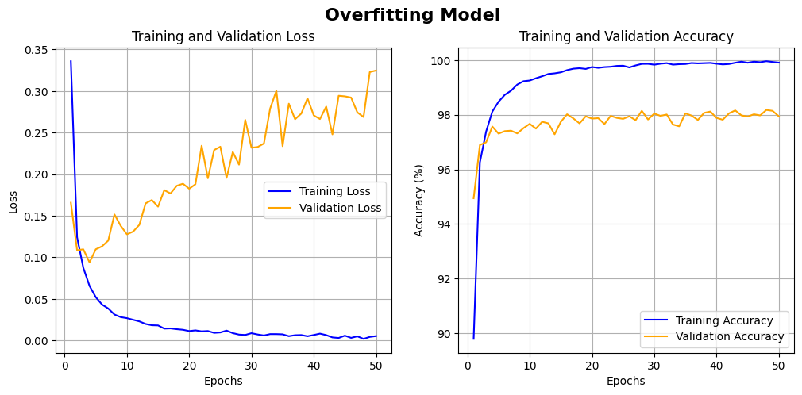

```python
# Plotting
fig, axes = plt.subplots(1, 2, figsize=(12, 5))
fig.suptitle('Overfitting Model', fontsize=16, fontweight='bold')
plot_training_loss(overfittedModel_history, axes)
plot_training_accuracy(overfittedModel_history, axes)
plt.show()
```

Based on the plots above, it demonstrates that this is an overfitting model.

On the loss plot, the training loss curve (blue) steadily goes down throughout the training, reaching a very low value which is near 0. This aligns with the model's increasing confidence on the training data. However, the validation loss curve (orange) keeps increasing, which indicates overfitting, as the model is essentially learning the specifics of the training data examples, which causes it to perform well on those specific examples but struggle with unseen data that could possibly have slightly different features or patterns.

It has a high training accuracy, which indicates that the model is fitting the training data very well. However, despite having a high training accuracy, the validation accuracy curve (orange) is much lower compared to the training accuracy. This also demonstrates overfitting as this means that the model is memorizing the training examples very well, failing to generalize to unseen data. Therefore there is an accuracy gap between the training and validation sets.

This model allows me to find where the border lies, whereby I can then tune it to find the ideal model, which is the next step.

# 8. Regularizing your model and tuning your hyperparameters

Now that we have found out where the border lies from the overfitting model, we can start to regularize the model and tune it to get as close as possible to the ideal model that neither underfits or overfits.

According to the DLWP book, these are some things to try to tune the model:

- Add dropout
- Try different architectures: add or remove layers
- Add L1 and/or L2 regularization
- Try different hyperparameters to find the optimal configuration
- Iterate on feature engineering: add new features, or remove features that don't seem to be informative.

I will try some of these, namely:

- Tuning hyperparameters (lowering epochs from 50 to 20)
- Adding dropout
- Adding L1 regularization
- Adding L2 regularization
- Adding Elastic Net regularization (both L1 and L2)

to try and find the ideal model.

## 8.1 Adding dropout (1st Model)

Firstly, I will proceed with the approach of adding dropout to the model. Neurons can develop a strong reliance on each other during training, which can lead the network to learn intricate patterns unique to the training data. Dropout helps to prevent overfitting as it randomly knocks out neurons every training iteration, preventing over-reliance on specific combination of neurons. I will be adding dropout to each of the layers except the last layer before the final output, because it can hinder the model's ability to make accurate classifications, as the layer leading up to the output layer have learned a condensed representation of the input data.

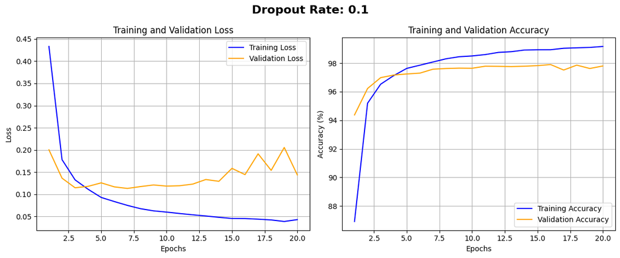

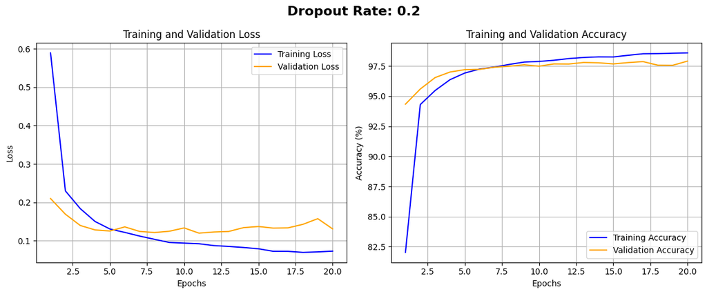

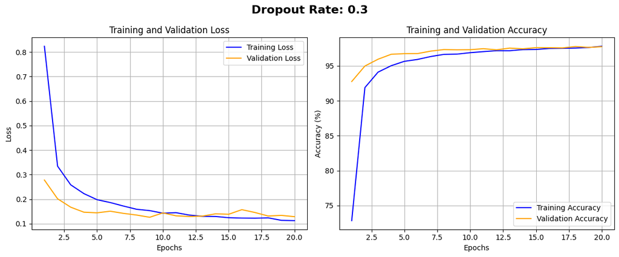

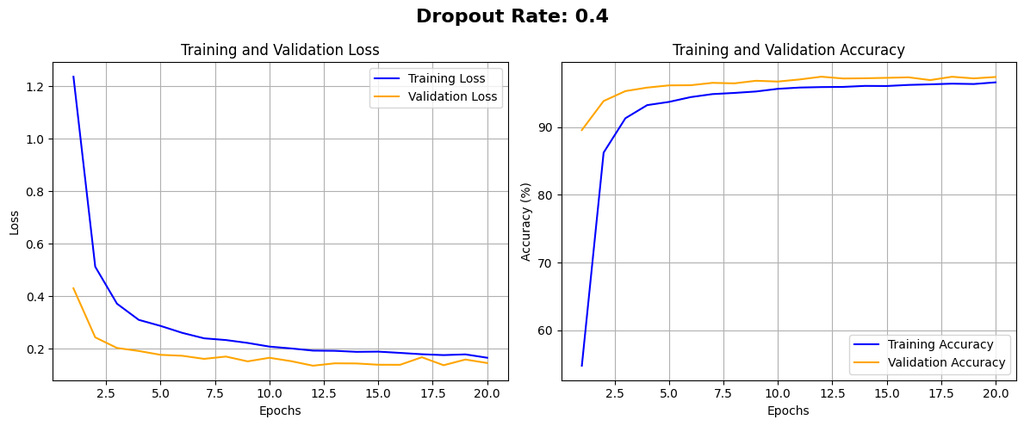

```python
# Dropout rates to experiment with
dropout_rates = [0.1, 0.2, 0.3, 0.4]

# For loop to test the model with the different dropout rates
for dropout_rate in dropout_rates:
    testingDropoutModel = Sequential([
                    # Added dropout to every layer except the final
                    Flatten(input_shape=INPUT_DIMENSION),
                    Dense(256, activation='relu'),
                    Dropout(dropout_rate),
                    Dense(128, activation='relu'),
                    Dropout(dropout_rate),
                    Dense(64, activation='relu'),
                    Dropout(dropout_rate),
                    Dense(64, activation='relu'),
                    Dropout(dropout_rate),
                    Dense(48, activation='relu'),
                    Dropout(dropout_rate),
                    Dense(32, activation='relu'),
                    Dense(OUTPUT_CLASSES, activation='softmax')
                    ], name='testingDropoutModel')

    testingDropoutModel.compile(optimizer=OPTIMIZER,
                                    loss=LOSS_FUNC, metrics=METRICS)


    # Training the model
    testingDropoutModel_history = testingDropoutModel.fit(X_train, y_train,
                                                            epochs=20, # Reduced the number of epochs
                                                            batch_size=64,
                                                            validation_data=(X_validation, y_validation),
                                                            verbose=0) #verbose = 0 so that it doesnt show anything
                                                                       #otherwise it will be too long

    # Plotting
    fig, axes = plt.subplots(1, 2, figsize=(12, 5))
    plot_training_loss(testingDropoutModel_history, axes)
    plot_training_accuracy(testingDropoutModel_history, axes)

    # Big header with the dropout rate used
    fig.suptitle('Dropout Rate: {:.1f}'.format(dropout_rate), fontsize=16, fontweight='bold')

    plt.tight_layout()
    plt.show()
```

These are the plots of the various dropout rates that I have tried to apply on my model.

### Observations:

**Dropout rate of 0.1:**

The training and validation loss plot (left) is already showing signs of overfitting. Compared to the overfitting model, The validation loss is not as intense at higher amounts of epochs. This means that the dropout is working to reduce overfitting.

However, there is still overfitting even after applying dropout rate of 0.1. The training loss curve (blue) reaching the minimum value quickly and flattening out, meaning that the model is being trained well and is learning well. The validation loss curve (orange) on the other hand, still has deviations and has more losses at higher epochs. This means that the model is not generalizing well.

The training and validation accuracy plot (right) also shows sign of overfitting. It reduced the overfitting compared to the original overfitted model, however it is still not enough as the validation accuracy curve (orange) is still lesser than that of the training accuracy curve (blue).

**Dropout rate of 0.2:**

Similar to the dropout rate of 0.1, both training and validation loss and accuracy plots still shows sign of overfitting. The amount of overfitting is reduced as we can see by both plots, whereby in the loss curve, the amount of validation loss is not as high as the dropout rate of 0.1, and in the training and validation accuracy curve, the validation accuracy curve (orange) is still lower than that of the training accuracy curve(blue).

**Dropout rate of 0.3:**

The dropout rate of 0.3 seems to be very effective in reducing overfitting as seen from the plots.

In the training and validation loss plots (left), the training loss curve (blue) reaches the minimum value relatively quickly and flattens out, which suggests that the model is learning well. The validation loss curve (orange) follows the training loss curve reasonably well also, without many deviations. This means that the model is generalizing well to unseen data.

In the training and validation accuracy plot (right), the training accuracy curve (blue) reaches a high value relatively quickly and maintains that value. This is indicative of good training performance. The validation accuracy curve (orange) is high and stays very close to the training accuracy curve, which is indicative that the model is performing well on unseen data.

**Dropout rate of 0.4:**

The dropout rate of 0.4 seems to be too strong in reducing the overfitting.

In the training and validation loss plots (left), the training loss curve (blue) is similar to the plot in 0.3, however it continues decreasing throughout the epochs. This could be a sign of underfitting. The validation loss curve (orange) deviates from the training loss curve which is also a sign of underfitting, where the model is not learning enough from the training data.

In the training and validation accuracy plot (right), the training accuracy curve (blue) is similar to the plot in 0.3, which means that the training performance is good. However, the validation accuracy curve has a bigger gap compared to the training accuracy curve, and the validation accuracy is higher than that of the training accuracy. This likely means that the dropout rate is too high, and that there is excessive dropout leading to over-regularization.

**Conclusion**

Out of all the dropout rates tested, the dropout rate of **0.3** seems to be the optimal dropout rate to use for my data, as explained through analysis of the various plots above. I will now proceed to try other forms of regularization to see if it fits my model better.

## 8.2 L1 Regularization (2nd Model)

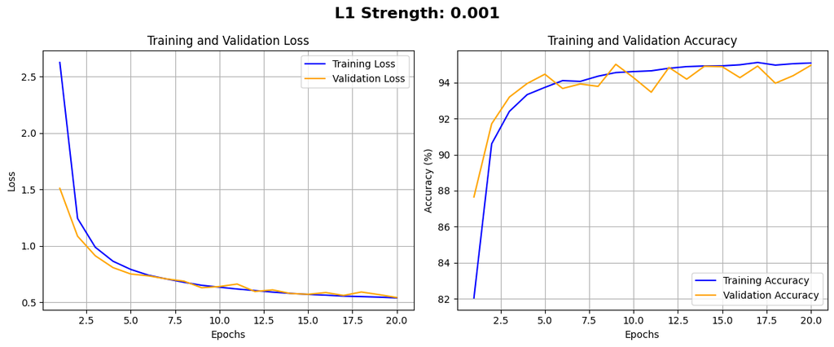

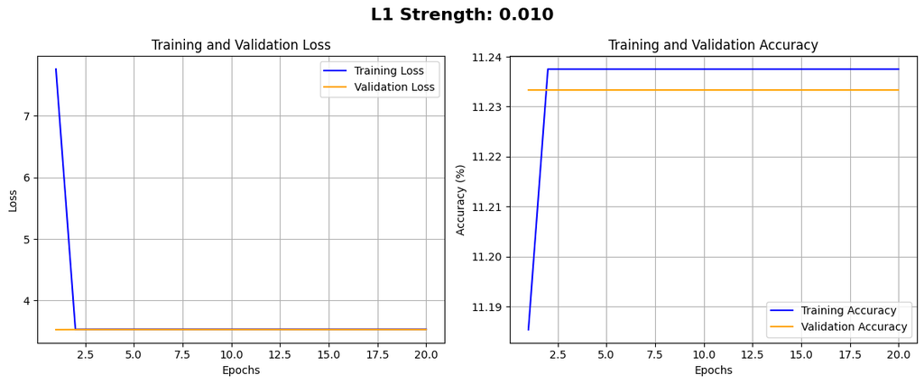

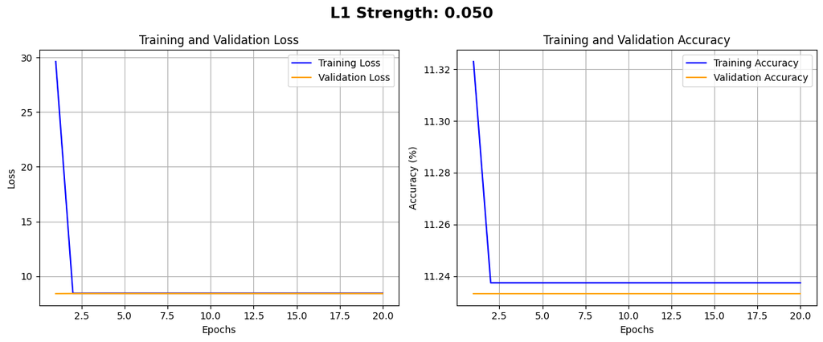

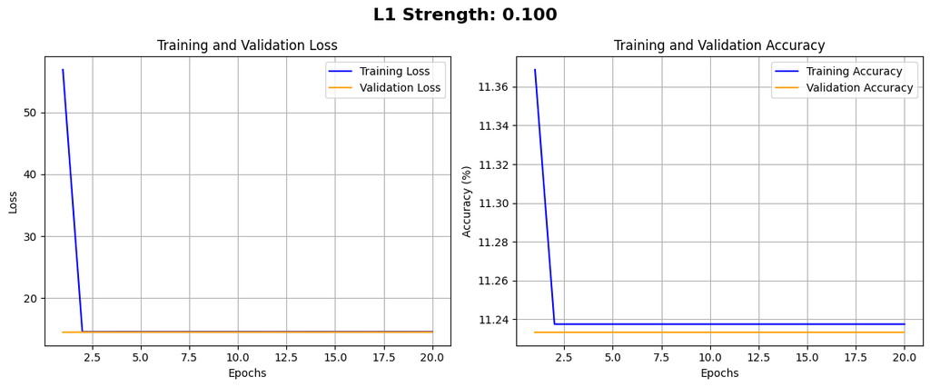

```python
from keras.regularizers import l1

# L1 strengths to experiment with
l1_strengths = [0.001, 0.01, 0.05, 0.1]

# For loop to test the model with the different L1 strengths
for l1_strength in l1_strengths:
    l1regularizationModel = Sequential([
        Flatten(input_shape=INPUT_DIMENSION),
        Dense(256, activation='relu', kernel_regularizer=l1(l1_strength)),
        Dense(128, activation='relu', kernel_regularizer=l1(l1_strength)),
        Dense(64, activation='relu', kernel_regularizer=l1(l1_strength)),
        Dense(64, activation='relu', kernel_regularizer=l1(l1_strength)),
        Dense(48, activation='relu', kernel_regularizer=l1(l1_strength)),
        Dense(32, activation='relu', kernel_regularizer=l1(l1_strength)),
        Dense(OUTPUT_CLASSES, activation='softmax')
    ], name='l1regularizationModel')

    # Compile the model
    l1regularizationModel.compile(optimizer=OPTIMIZER,
                                loss=LOSS_FUNC, metrics=METRICS)


    # Train the model
    l1regularizationModel_history = l1regularizationModel.fit(X_train, y_train,
                                                            epochs=20,
                                                            batch_size=64,
                                                            validation_data=(X_validation, y_validation),
                                                            verbose=0)

    # Plotting
    fig, axes = plt.subplots(1, 2, figsize=(12, 5))
    plot_training_loss(l1regularizationModel_history, axes)
    plot_training_accuracy(l1regularizationModel_history, axes)

    # Big header with the L1 strength used
    fig.suptitle('L1 Strength: {:.3f}'.format(l1_strength), fontsize=16, fontweight='bold')

    plt.tight_layout()
    plt.show()
```

These are the plots of the various L1 regularization strengths that I have tried to apply on my model.

Based on these plots, it can be seen that the L1 strength of 0.001 is the optimal strength to apply to the model to curb the overfitting. The other L1 strengths applied - 0.01, 0.05, 0.1 looks to be too strong, causing the validation accuracy to drop to around 10-11%, and the loss to be significantly higher than even the overfitting or initial model. This is probably because the high regularization strength is hindering the model's learning ability, causing severe underfitting to occur, which is likely the reason for the plots to be 'flatlined'.

Therefore, the optimal L1 strength to apply to my model is **0.001.**

I will continue on with other regularization methods before making a comparison.

## 8.3 L2 Regularization (3rd Model)

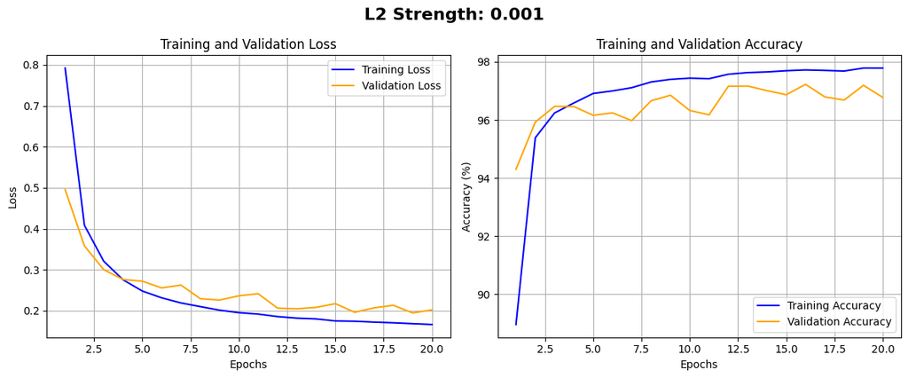

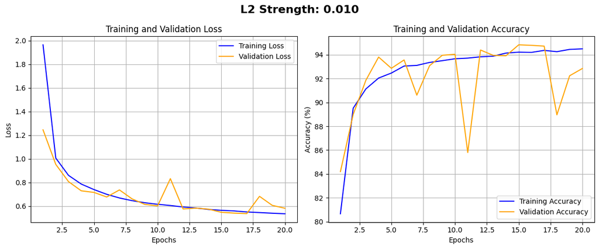

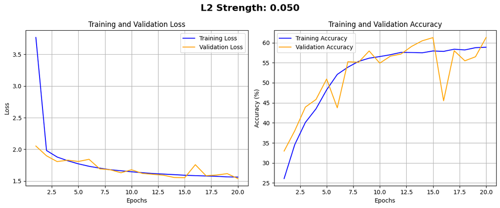

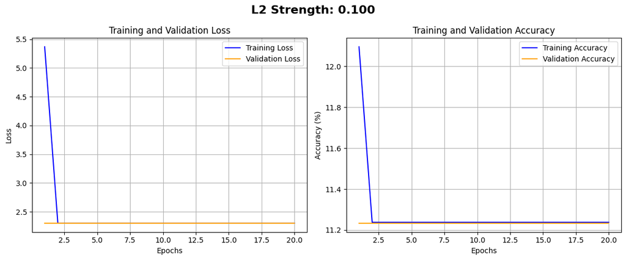

```python
from keras.regularizers import l2

# L2 strengths to experiment with
l2_strengths = [0.001, 0.01, 0.05, 0.1]

# For loop to test the model with the different L2 strengths
for l2_strength in l2_strengths:
    l2regularizationModel = Sequential([
        Flatten(input_shape=INPUT_DIMENSION),
        Dense(256, activation='relu', kernel_regularizer=l2(l2_strength)),
        Dense(128, activation='relu', kernel_regularizer=l2(l2_strength)),
        Dense(64, activation='relu', kernel_regularizer=l2(l2_strength)),
        Dense(64, activation='relu', kernel_regularizer=l2(l2_strength)),
        Dense(48, activation='relu', kernel_regularizer=l2(l2_strength)),
        Dense(32, activation='relu', kernel_regularizer=l2(l2_strength)),
        Dense(OUTPUT_CLASSES, activation='softmax')
    ], name='l2regularizationModel')

    # Compile the model
    l2regularizationModel.compile(optimizer=OPTIMIZER,
                                loss=LOSS_FUNC, metrics=METRICS)


    # Train the model
    l2regularizationModel_history = l2regularizationModel.fit(X_train, y_train,
                                                            epochs=20,
                                                            batch_size=64,
                                                            validation_data=(X_validation, y_validation),
                                                            verbose=0)

    # Plotting
    fig, axes = plt.subplots(1, 2, figsize=(12, 5))
    plot_training_loss(l2regularizationModel_history, axes)
    plot_training_accuracy(l2regularizationModel_history, axes)

    # Big header with the L2 strength used
    fig.suptitle('L2 Strength: {:.3f}'.format(l2_strength), fontsize=16, fontweight='bold')

    plt.tight_layout()
    plt.show()
```

Similar to the plots of the varying L1 strengths, the L2 strength of 0.1 seems to be too strong, causing the model to not learn properly, resulting in the 'flatline' in the plots. Therefore, this strength is not suitable for the model.

The L2 strength of 0.050 seems to also be too strong, as the accuracy for both the training and the validation accuracy is not very high, meaning that the regularization is inhibiting the model's ability. Therefore, this strength is also not suitable for this model.

**For the L2 strength of 0.01:**

In the training and validation loss plot, the training loss curve (blue) starts high and steadily decreases over epochs, which indicates that the model is learning from the trainin data. The validation loss (orange) also shows a downward trend, however it fluctuates more than the training loss curve. This could be because the model is attempting to learn from the validation data, whereby the dips imply that the model might be finding certain useful patterns, but struggles to maintain that progress.

In the training and validation accuracy plot, the training loss curve (blue) starts low and reaches a high accuracy after a few epochs, indicative of the model fitting the data well. However, the validation accuracy curve (orange) fluctuates throughout training, which is likely due to overfitting, whereby the model memorizing the training examples but failing to generalize well to unseen data in the validation set.

**For the L2 strength of 0.001:**

In the training and validation loss plot, similar to the one for the l2 strength of 0.01, the training loss curve (blue) also indicates that the model is learning from the training data. The validation loss curve (orange) fluctuates also, but the overall trend is promising compared to the l2 strength of 0.01, as the fluctuations are smooth and not random dips, meaning that the model is generalizing somewhat to the unseen validation data.

In the training and validation accuracy plot, the validation accuracy curve (orange) fluctuates as well, but also not as intensive as the l2 strength of the 0.01. Even though the validation accuracy curve is lower than the training accuracy, the gap between the validation accuracy curve and the training accuracy curve (blue) is not as large as the l2 strength of 0.01. This means that even though there is still overfitting present, **the L2 strength of 0.001 is still better than the L2 strength of 0.01.**

I will now continue on with another regularization method.

## 8.4 Elastic Net Regularization (Both L1 and L2, 4th Model)

I will perform Elastic Net Regularization now using a range of values based on the best L1 and L2 strength when tested individually above. In my opinion, the best L1 and L2 strength individually is L1 = 0.001, and L2 = 0.001. I will now try different strength combinations around these range to try and find a best fit for the model.

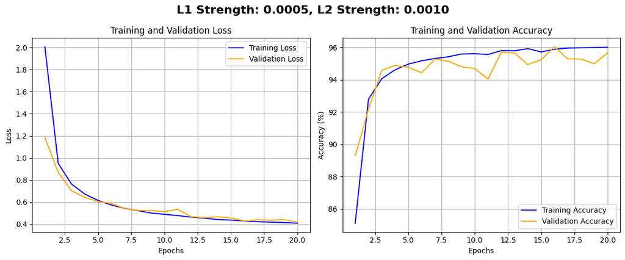

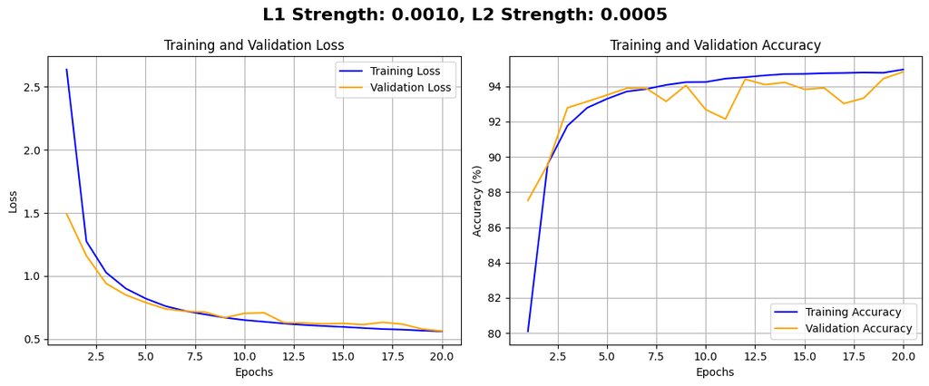

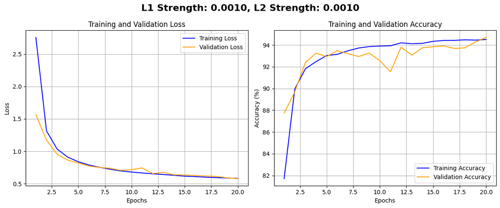

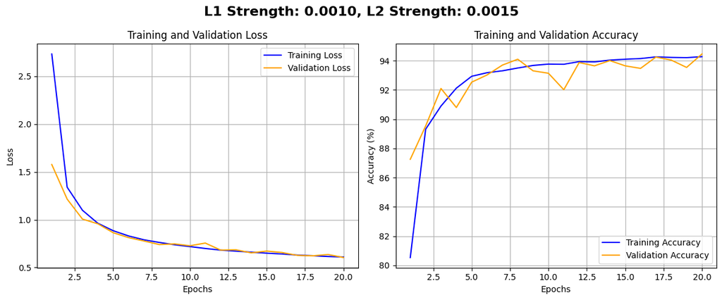

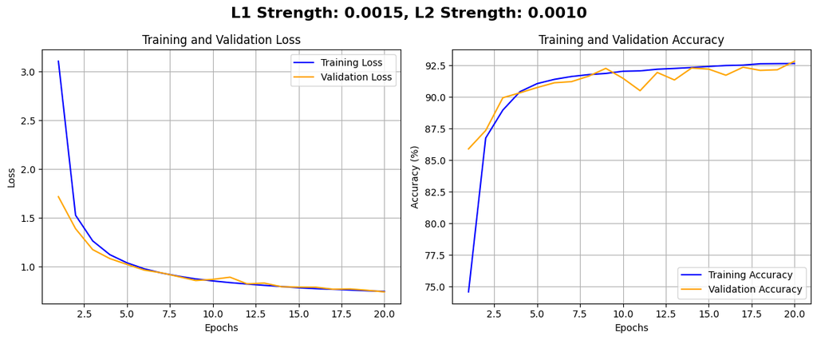

```python
from keras.regularizers import l1_l2

# Experiment with different combinations within the range
strength_combinations = [
    (0.0005, 0.001),    # Lower L1, optimal L2
    (0.001, 0.0005),    # Optimal L1, lower L2
    (0.001, 0.001),     # Optimal for both individually
    (0.001, 0.0015),    # Slightly higher L2
    (0.0015, 0.001)     # Slightly higher L1
]

# For loop to test the model with the different L1/L2 strength combinations
for l1_strength, l2_strength in strength_combinations:
    elasticNet_model = Sequential([
        Flatten(input_shape=INPUT_DIMENSION),
        Dense(256, activation='relu', kernel_regularizer=l1_l2(l1=l1_strength, l2=l2_strength)),
        Dense(128, activation='relu', kernel_regularizer=l1_l2(l1=l1_strength, l2=l2_strength)),
        Dense(64, activation='relu', kernel_regularizer=l1_l2(l1=l1_strength, l2=l2_strength)),
        Dense(64, activation='relu', kernel_regularizer=l1_l2(l1=l1_strength, l2=l2_strength)),
        Dense(48, activation='relu', kernel_regularizer=l1_l2(l1=l1_strength, l2=l2_strength)),
        Dense(32, activation='relu', kernel_regularizer=l1_l2(l1=l1_strength, l2=l2_strength)),
        Dense(OUTPUT_CLASSES, activation='softmax')
    ], name='elasticNet_model')

    # Compile the model
    elasticNet_model.compile(optimizer=OPTIMIZER,
                                loss=LOSS_FUNC, metrics=METRICS)


    # Train the model
    elasticNet_model_history = elasticNet_model.fit(X_train, y_train,
                                                            epochs=20,
                                                            batch_size=64,
                                                            validation_data=(X_validation, y_validation),
                                                            verbose=0)

    # Plotting
    fig, axes = plt.subplots(1, 2, figsize=(12, 5))
    plot_training_loss(elasticNet_model_history, axes)
    plot_training_accuracy(elasticNet_model_history, axes)

    # Big header with the L1 and L2 strength used
    fig.suptitle('L1 Strength: {:.4f}, L2 Strength: {:.4f}'.format(l1_strength, l2_strength), fontsize=16, fontweight='bold')

    plt.tight_layout()
    plt.show()
```

With reference to the plots above of the different combination of L1 and L2 regularization strengths applied to the model, in my opinion, the best L1 and L2 strength combination to use would be L1 = 0.001, and L2 = 0.0005. This is because in the models such as:

- L1 = 0.0005, L2 = 0.001
- L1 = 0.001, L2 = 0.001
- L1 = 0.001, L2 = 0.0015

The training and validation accuracy plots for these L1 and L2 strengths have a lot of fluctuations on the validation accuracy curve (orange). This suggests that the model is not generalising well consistently.

For the remaining models:

## 8.5 Elastic Net Regularization with Dropout (5th Model)

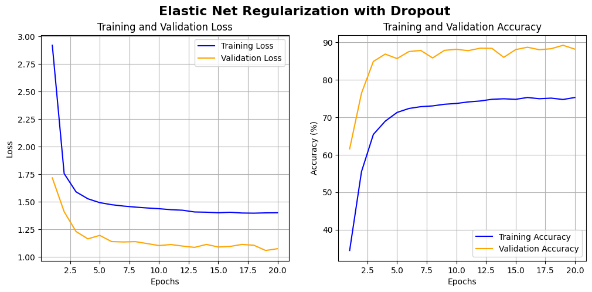

```python
# Optimal L1/L2 Strengths
l1_strength = 0.001
l2_strength = 0.0005

# Optimal dropout rate
dropout_rate = 0.3


elasticNetWithDropout_model = Sequential([
        Flatten(input_shape=INPUT_DIMENSION),
        Dense(256, activation='relu', kernel_regularizer=l1_l2(l1=l1_strength, l2=l2_strength)),
        Dropout(dropout_rate),
        Dense(128, activation='relu', kernel_regularizer=l1_l2(l1=l1_strength, l2=l2_strength)),
        Dropout(dropout_rate),
        Dense(64, activation='relu', kernel_regularizer=l1_l2(l1=l1_strength, l2=l2_strength)),
        Dropout(dropout_rate),
        Dense(64, activation='relu', kernel_regularizer=l1_l2(l1=l1_strength, l2=l2_strength)),
        Dropout(dropout_rate),
        Dense(48, activation='relu', kernel_regularizer=l1_l2(l1=l1_strength, l2=l2_strength)),
        Dropout(dropout_rate),
        Dense(32, activation='relu', kernel_regularizer=l1_l2(l1=l1_strength, l2=l2_strength)),
        Dropout(dropout_rate),
        Dense(OUTPUT_CLASSES, activation='softmax')
], name='elasticNetWithDropout_model')

# Compile the model
elasticNetWithDropout_model.compile(optimizer=OPTIMIZER,
                             loss=LOSS_FUNC, metrics=METRICS)

# Train the model
elasticNetWithDropout_model_history = elasticNetWithDropout_model.fit(X_train, y_train,
                                                epochs=20,
                                                batch_size=64,
                                                validation_data=(X_validation, y_validation),
                                                verbose=0)

# Plotting
fig, axes = plt.subplots(1, 2, figsize=(12, 5))
fig.suptitle('Elastic Net Regularization with Dropout', fontsize=16, fontweight='bold')
plot_training_loss(elasticNetWithDropout_model_history, axes)
plot_training_accuracy(elasticNetWithDropout_model_history, axes)
plt.show()
```

The above is the Elastic Net Regularization with dropout plot.

On the training and validation loss plot, the training loss curve (blue) is relatively flat across epochs, this indicates that the model is not effectively learning from the data to reduce the loss. The validation loss curve (orange) is also relatively flat and has certain areas where it increases across epochs. This also indicates that the model's performance on unseen data is not improving as training progresses, which is a sign of underfitting.

On the training and validation accuracy plot, The training accuracy curve (blue) is relatively flat across epochs also, hovering around 75%, indicating that the model is not effectively learning from the training data to improve. The validation accuracy curve (orange) is much higher than that of the training accuracy curve. This is likely due to the combination of the L1 and L2 regularization together with dropout. Regularization prevents the model from overfitting to the training data. This limits the model's ability to fit to the training data with high accuracy. On the other hand, because validation accuracy measures performance on an unseen dataset, it is likely to beenfit from the overfitting-prevention mechanisms which are induced by the regularization. This causes the model to better capture the true underlying patterns in the data rather than memorizing the training data, which results in the higher validation accuracy.

# 9. Evaluating on Test set

After trying out different regularization methods, in my opinion, the optimal model is the one with the Elastic Net Regularization, with L1 strength being 0.001, and L2 strength being 0.0005. The dropout rate of 0.3 is a strong contender, however, it's validation loss across epochs is not as stable as that of the elastic net regularization. Therefore in my opinion, the optimal model is the one with the elastic net regularization.

The regularization and parameter tuning was very time consuming as it takes a long time to run each training epoch when the data is being traned.

Given the limited time I had, I am not able to perform more tests on different parameters to possibly obtain an even more optimal model. With the time that I had, I managed to develop a usable model that works well on this dataset.

Below will be the optimal model being tested on the test set which I preprocessed earlier.

```python
from keras.callbacks import ModelCheckpoint

# Optimal model
l1_strength = 0.001
l2_strength = 0.0005

# Filepath to store the model
filepath = "C:/Users/Zhong Da Goh/Desktop/MLNN/saved_models/best_model.h5"

checkpoint = ModelCheckpoint(filepath,
                             monitor='val_categorical_accuracy',
                             verbose=1,
                             save_best_only=True,
                             mode='max')

optimal_model = Sequential([
        Flatten(input_shape=INPUT_DIMENSION),
        Dense(256, activation='relu', kernel_regularizer=l1_l2(l1=l1_strength, l2=l2_strength)),
        Dense(128, activation='relu', kernel_regularizer=l1_l2(l1=l1_strength, l2=l2_strength)),
        Dense(64, activation='relu', kernel_regularizer=l1_l2(l1=l1_strength, l2=l2_strength)),
        Dense(64, activation='relu', kernel_regularizer=l1_l2(l1=l1_strength, l2=l2_strength)),
        Dense(48, activation='relu', kernel_regularizer=l1_l2(l1=l1_strength, l2=l2_strength)),
        Dense(32, activation='relu', kernel_regularizer=l1_l2(l1=l1_strength, l2=l2_strength)),
        Dense(OUTPUT_CLASSES, activation='softmax')
], name='optimal_model')

# Compile the model
optimal_model.compile(optimizer=OPTIMIZER,
                            loss=LOSS_FUNC, metrics=METRICS)


# Train the model
optimal_model_history = optimal_model.fit(X_train, y_train,
                                                        epochs=20,
                                                        batch_size=64,
                                                        validation_data=(X_validation, y_validation),
                                                        callbacks=[checkpoint],
                                                        verbose=0)
```

```
Epoch 1: val_categorical_accuracy improved from -inf to 0.89308, saving model to C:/Users/Zhong Da Goh/Desktop/MLNN/saved_models\best_model.h5

Epoch 2: val_categorical_accuracy improved from 0.89308 to 0.90308, saving model to C:/Users/Zhong Da Goh/Desktop/MLNN/saved_models\best_model.h5

Epoch 3: val_categorical_accuracy improved from 0.90308 to 0.92358, saving model to C:/Users/Zhong Da Goh/Desktop/MLNN/saved_models\best_model.h5

Epoch 4: val_categorical_accuracy improved from 0.92358 to 0.93433, saving model to C:/Users/Zhong Da Goh/Desktop/MLNN/saved_models\best_model.h5

Epoch 5: val_categorical_accuracy did not improve from 0.93433

Epoch 6: val_categorical_accuracy did not improve from 0.93433

Epoch 7: val_categorical_accuracy improved from 0.93433 to 0.93508, saving model to C:/Users/Zhong Da Goh/Desktop/MLNN/saved_models\best_model.h5

Epoch 8: val_categorical_accuracy improved from 0.93508 to 0.94200, saving model to C:/Users/Zhong Da Goh/Desktop/MLNN/saved_models\best_model.h5

Epoch 9: val_categorical_accuracy did not improve from 0.94200

Epoch 10: val_categorical_accuracy improved from 0.94200 to 0.94225, saving model to C:/Users/Zhong Da Goh/Desktop/MLNN/saved_models\best_model.h5

Epoch 11: val_categorical_accuracy did not improve from 0.94225

Epoch 12: val_categorical_accuracy improved from 0.94225 to 0.94375, saving model to C:/Users/Zhong Da Goh/Desktop/MLNN/saved_models\best_model.h5

Epoch 13: val_categorical_accuracy improved from 0.94375 to 0.94483, saving model to C:/Users/Zhong Da Goh/Desktop/MLNN/saved_models\best_model.h5

Epoch 14: val_categorical_accuracy did not improve from 0.94483

Epoch 15: val_categorical_accuracy did not improve from 0.94483

Epoch 16: val_categorical_accuracy did not improve from 0.94483

Epoch 17: val_categorical_accuracy improved from 0.94483 to 0.94708, saving model to C:/Users/Zhong Da Goh/Desktop/MLNN/saved_models\best_model.h5

Epoch 18: val_categorical_accuracy did not improve from 0.94708

Epoch 19: val_categorical_accuracy did not improve from 0.94708

Epoch 20: val_categorical_accuracy improved from 0.94708 to 0.94808, saving model to C:/Users/Zhong Da Goh/Desktop/MLNN/saved_models\best_model.h5
```

```python
from keras.models import load_model

# Loading the model
best_model = load_model("C:/Users/Zhong Da Goh/Desktop/MLNN/saved_models/best_model.h5")

# Generate predictions
predictions = best_model.predict(X_test)

# Get predicted class labels
predicted_classes = np.argmax(predictions, axis=-1)

# Calculate and print accuracy
accuracy = accuracy_score(y_test, predicted_classes)

# Print accuracy in percentage
accuracy_percentage = accuracy * 100
print("Test Accuracy: {:.2f}%".format(accuracy_percentage))
```

```
Test Accuracy: 95.28%
```

# 10. Conclusion

In conclusion, through this project, I was able to develop a model that works well on this MNIST classification type of dataset. Testing it on the test samples gave a test accuracy of 95.28%, which is a very high accuracy score.

I have also proved my hypotheses correct that it is possible to predict the output with a given input as there should exist a predictive relationship between the pixel values of an input image and its corresponding label.

The other hypothesis that I proved correct through this model is that the MNIST dataset provided is sufficiently informative to learn the relationship between inputs and outputs.

Given more time, I would try to optimize it more by further tuning the model, adjusting its hyperparameters and trying out different strengths of regularizations, or adding different regularizations to different layers.

## References

Chollet, F. (2019) Chapter 4. Fundamentals of machine learning · Deep Learning with python, · Deep Learning with Python. Available at: https://livebook.manning.com/book/deep-learning-with-python/chapter-4/161

Lehn, F. vom. (2023, November 8). Interpreting training/validation accuracy and loss. Medium. https://medium.com/@frederik.vl/interpreting-training-validation-accuracy-and-loss-cf16f0d5329f

Mnist | tensorflow datasets. (n.d.). TensorFlow. from https://www.tensorflow.org/datasets/catalog/mnist

Otten, N. V. (2023, May 26). L1 and l2 regularization explained, when to use them & practical how to examples. Spot Intelligence. https://spotintelligence.com/2023/05/26/l1-l2-regularization/

Pykes, K. (2022, July 22). Fighting overfitting with l1 or l2 regularization: Which one is better? Neptune.Ai. https://neptune.ai/blog/fighting-overfitting-with-l1-or-l2-regularization

Tf. Keras. Utils. To_categorical | tensorflow v2. 15. 0. Post1. (n.d.). TensorFlow. from https://www.tensorflow.org/api_docs/python/tf/keras/utils/to_categorical

5.6. Dropout—Dive into Deep Learning 1.0.3 documentation. (n.d.). from https://d2l.ai/chapter_multilayer-perceptrons/dropout.html